# 重賞レース予測レポート【レース終了】

作成日時: 2025/12/28 16:30:14

☞ [マニュアル(pdf)](https://ryutoro-galois.github.io/keiba-predictor/manual/manual.pdf)

☞ 過去5年の同一レース結果: [2024年](https://ryutoro-galois.github.io/keiba-predictor/report/PredResult_2024y_raceDate_20241221_20241222.html), [2023年](https://ryutoro-galois.github.io/keiba-predictor/report/PredResult_2023y_raceDate_20231223_20231224.html), [2022年](https://ryutoro-galois.github.io/keiba-predictor/report/PredResult_2022y_raceDate_20221224_20221225.html), [2021年](https://ryutoro-galois.github.io/keiba-predictor/report/PredResult_2021y_raceDate_20211225_20211226.html), [2020年](https://ryutoro-galois.github.io/keiba-predictor/report/PredResult_2020y_raceDate_20201226_20201227.html)

☞ 過去4週間の別レース結果: [1週前(12/20-21)](https://ryutoro-galois.github.io/keiba-predictor/report/PredResult_2025y_raceDate_20251220_20251221.html), [2週前(12/13-14)](https://ryutoro-galois.github.io/keiba-predictor/report/PredResult_2025y_raceDate_20251213_20251214.html), [3週前(12/6-7)](https://ryutoro-galois.github.io/keiba-predictor/report/PredResult_2025y_raceDate_20251206_20251207.html), [4週前(11/29-30)](https://ryutoro-galois.github.io/keiba-predictor/report/PredResult_2025y_raceDate_20251129_20251130.html)

☞ netkeiba: [中山大障害(JGI)](https://race.netkeiba.com/race/result.html?race_id=202506050710&rf=race_submenu), [ホープフルステークス(GI)](https://race.netkeiba.com/race/result.html?race_id=202506050711&rf=race_submenu), [阪神カップ(GⅡ)](https://race.netkeiba.com/race/result.html?race_id=202509050711&rf=race_submenu), [有馬記念(GI)](https://race.netkeiba.com/race/result.html?race_id=202506050811&rf=race_submenu)

☞ レース結果(csv): [12/27-28](https://ryutoro-galois.github.io/keiba-predictor/csv/race_result_20251227_20251228.csv)

## 【レース結果(1)】人気と着順の関係

### 【中山大障害(2025/12/27(土))】

【中山大障害(J.GⅠ)】  
2025/12/27(土), 06_中山, 障芝4100m

[interactive chart not shown]

### 【ホープフルステークス(2025/12/27(土))】

【ホープフルステークス(GⅠ)】  
2025/12/27(土), 06_中山, 芝右2000m

[interactive chart not shown]

### 【阪神カップ(2025/12/27(土))】

【阪神カップ(GⅡ)】  
2025/12/27(土), 09_阪神, 芝右1400m

[interactive chart not shown]

### 【有馬記念(2025/12/28(日))】

【有馬記念(GⅠ)】  
2025/12/28(日), 06_中山, 芝右2500m

[interactive chart not shown]

## 【レース結果(2)】コーナー通過順位

### 【中山大障害(2025/12/27(土))】

【中山大障害(J.GⅠ)】  
2025/12/27(土), 06_中山, 障芝4100m

[interactive chart not shown]

### 【ホープフルステークス(2025/12/27(土))】

【ホープフルステークス(GⅠ)】  
2025/12/27(土), 06_中山, 芝右2000m

[interactive chart not shown]

### 【阪神カップ(2025/12/27(土))】

【阪神カップ(GⅡ)】  
2025/12/27(土), 09_阪神, 芝右1400m

[interactive chart not shown]

### 【有馬記念(2025/12/28(日))】

【有馬記念(GⅠ)】  
2025/12/28(日), 06_中山, 芝右2500m

[interactive chart not shown]

## 0. 推し馬予測 (AI予測)

### 【中山大障害(J.GⅠ) 2025/12/27(土)】

- 本命(◎): 1-3着内確率(勝負強さ)が1位の馬
- 対抗(◯): 1-3着内確率が2-N位(20%程度以上)の中で予測タイムが最も速い馬
- 3番手(▲): 1-3着内確率が2-N位(20%程度以上)のでダークホース確率が最も高い馬
- 穴: ダークホース確率が上位1-M位(40%程度以上)の中で1-3着内確率が最も高い馬

| 推し馬 | 枠番 | 馬番 | 人気 | オッズ | 馬名 | 騎手 | 調教師 | 予測タイム(sec) | 1_順位 | 1-3着内確率(%) | 2_順位 | ﾀﾞｰｸﾎｰｽ確率(%) | 3_順位 |
| --- | --- | --- | --- | --- | --- | --- | --- | --- | --- | --- | --- | --- | --- |
| 本命(◎) | 4 | 4 | 1 | 1.5 | エコロデュエル | 草野太郎 | 岩戸孝樹 | 276.1 | 1.0 | 29.0 | 1 | 0.5 | 9 |
| 対抗(◯) | 7 | 7 | 4 | 10.6 | フェーレンベルク | 上野翔 | 千葉直人 | 289.6 | 4.5 | 21.3 | 3 | 1.3 | 7 |
| 3番手(▲) | 1 | 1 | 2 | 3.7 | ネビーイーム | 小牧加矢太 | 佐々木晶三 | 290.2 | 6.0 | 25.6 | 2 | 0.6 | 8 |
| 穴 | 7 | 8 | 9 | 163.9 | アルデドゥオーモ | 伴啓太 | 矢野英一 | 292.9 | 7.0 | 12.1 | 6 | 57.7 | 2 |

### 【ホープフルステークス(GⅠ) 2025/12/27(土)】

- 本命(◎): 1-3着内確率(勝負強さ)が1位の馬
- 対抗(◯): 1-3着内確率が2-N位(20%程度以上)の中で予測タイムが最も速い馬
- 3番手(▲): 1-3着内確率が2-N位(20%程度以上)のでダークホース確率が最も高い馬
- 穴: ダークホース確率が上位1-M位(40%程度以上)の中で1-3着内確率が最も高い馬

| 推し馬 | 枠番 | 馬番 | 人気 | オッズ | 馬名 | 騎手 | 調教師 | 予測タイム(sec) | 1_順位 | 1-3着内確率(%) | 2_順位 | ﾀﾞｰｸﾎｰｽ確率(%) | 3_順位 |
| --- | --- | --- | --- | --- | --- | --- | --- | --- | --- | --- | --- | --- | --- |
| 本命(◎) | 1 | 2 | 6 | 16.0 | アーレムアレス | 菱田裕二 | 橋口慎介 | 127.4 | 10.5 | 30.2 | 1 | 1.2 | 11 |
| 対抗(◯) | 2 | 3 | 2 | 4.6 | ジャスティンビスタ | 北村友一 | 吉岡辰弥 | 121.4 | 1.5 | 28.4 | 2 | 0.6 | 12 |
| 3番手(▲) | 8 | 15 | 9 | 32.9 | アスクエジンバラ | 岩田康誠 | 福永祐一 | 127.1 | 4.0 | 20.6 | 9 | 43.2 | 6 |
| 穴 | 1 | 1 | 10 | 37.9 | ノチェセラーダ | Ａ．プーシャン | 杉山佳明 | 127.4 | 10.5 | 19.7 | 10 | 40.5 | 8 |

### 【阪神カップ(GⅡ) 2025/12/27(土)】

- 本命(◎): 1-3着内確率(勝負強さ)が1位の馬
- 対抗(◯): 1-3着内確率が2-N位(20%程度以上)の中で予測タイムが最も速い馬
- 3番手(▲): 1-3着内確率が2-N位(20%程度以上)のでダークホース確率が最も高い馬
- 穴: ダークホース確率が上位1-M位(40%程度以上)の中で1-3着内確率が最も高い馬

| 推し馬 | 枠番 | 馬番 | 人気 | オッズ | 馬名 | 騎手 | 調教師 | 予測タイム(sec) | 1_順位 | 1-3着内確率(%) | 2_順位 | ﾀﾞｰｸﾎｰｽ確率(%) | 3_順位 |
| --- | --- | --- | --- | --- | --- | --- | --- | --- | --- | --- | --- | --- | --- |
| 本命(◎) | 4 | 7 | 4 | 8.1 | フォーチュンタイム | 団野大成 | 吉岡辰弥 | 83.4 | 6 | 45.4 | 1 | 0.7 | 15 |
| 対抗(◯) | 5 | 9 | 2 | 6.4 | ジューンブレア | 武豊 | 武英智 | 82.5 | 2 | 40.4 | 2 | 0.7 | 14 |
| 3番手(▲) | 6 | 11 | 5 | 9.2 | ダノンマッキンリー | Ｃ．デムーロ | 藤原英昭 | 83.3 | 4 | 33.1 | 3 | 1.4 | 12 |
| 穴 | 4 | 8 | 16 | 348.0 | アスクワンタイム | 西塚洸二 | 梅田智之 | 84.8 | 9 | 7.4 | 12 | 53.5 | 1 |

### 【有馬記念(GⅠ) 2025/12/28(日)】

- 本命(◎): 1-3着内確率(勝負強さ)が1位の馬
- 対抗(◯): 1-3着内確率が2-N位(20%程度以上)の中で予測タイムが最も速い馬
- 3番手(▲): 1-3着内確率が2-N位(20%程度以上)のでダークホース確率が最も高い馬
- 穴: ダークホース確率が上位1-M位(40%程度以上)の中で1-3着内確率が最も高い馬

| 推し馬 | 枠番 | 馬番 | 人気 | オッズ | 馬名 | 騎手 | 調教師 | 予測タイム(sec) | 1_順位 | 1-3着内確率(%) | 2_順位 | ﾀﾞｰｸﾎｰｽ確率(%) | 3_順位 |
| --- | --- | --- | --- | --- | --- | --- | --- | --- | --- | --- | --- | --- | --- |
| 本命(◎) | 3 | 5 | 1 | 3.3 | レガレイラ | Ｃ．ルメール | 木村哲也 | 151.9 | 2 | 35.4 | 1 | 0.7 | 13 |
| 対抗(◯) | 2 | 4 | 3 | 3.8 | ミュージアムマイル | Ｃ．デムーロ | 高柳大輔 | 151.9 | 2 | 29.1 | 3 | 0.6 | 14 |
| 3番手(▲) | 8 | 16 | 8 | 35.4 | タスティエーラ | 松山弘平 | 堀宣行 | 155.6 | 5 | 22.3 | 4 | 2.2 | 9 |
| 穴 | 6 | 12 | 11 | 111.5 | マイネルエンペラー | 丹内祐次 | 清水久詞 | 156.8 | 7 | 10.8 | 9 | 41.3 | 2 |

## 1. 予測チャート (タイム/勝負強さ)

### 【中山大障害(J.GⅠ)】

2025/12/27(土), 06_中山, 障芝4100m

[interactive chart not shown]

### 【ホープフルステークス(GⅠ)】

2025/12/27(土), 06_中山, 芝右2000m

[interactive chart not shown]

### 【阪神カップ(GⅡ)】

2025/12/27(土), 09_阪神, 芝右1400m

[interactive chart not shown]

### 【有馬記念(GⅠ)】

2025/12/28(日), 06_中山, 芝右2500m

[interactive chart not shown]

## 2. オッズモニタリング (毎時)

### 【中山大障害】

[interactive chart not shown]

### 【ホープフルステークス】

[interactive chart not shown]

### 【阪神カップ】

[interactive chart not shown]

### 【有馬記念】

[interactive chart not shown]

## 3. 出馬表

### 【中山大障害 2025/12/27(土) 】

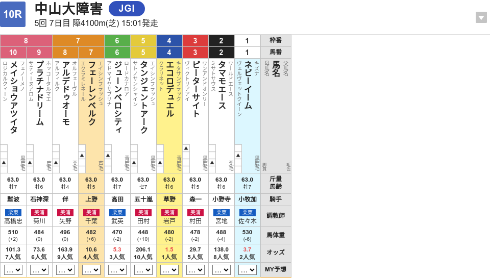

### 【ホープフルステークス 2025/12/27(土) 】

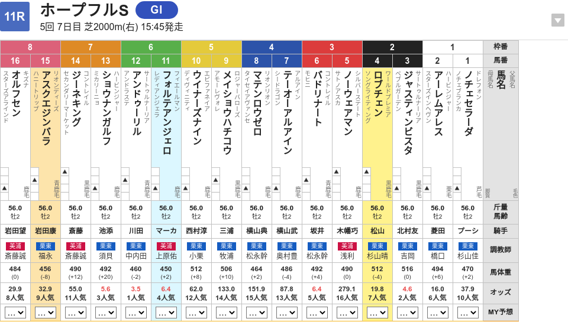

### 【阪神カップ 2025/12/27(土) 】

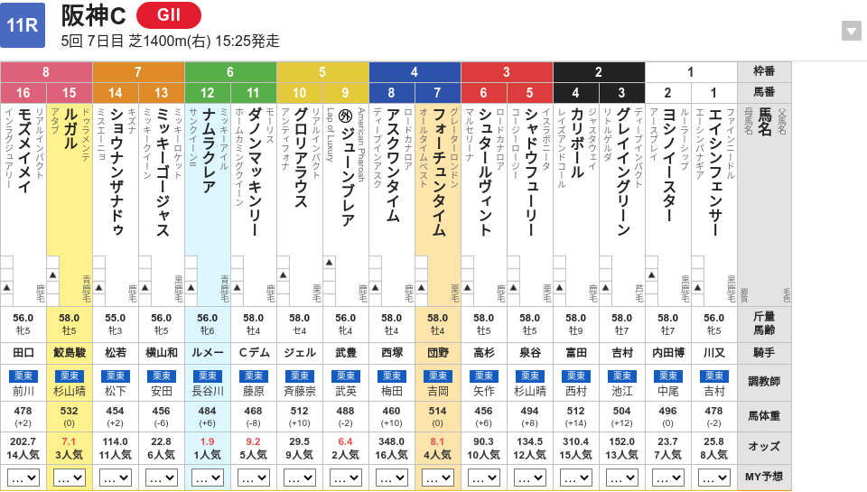

### 【有馬記念 2025/12/28(日) 】

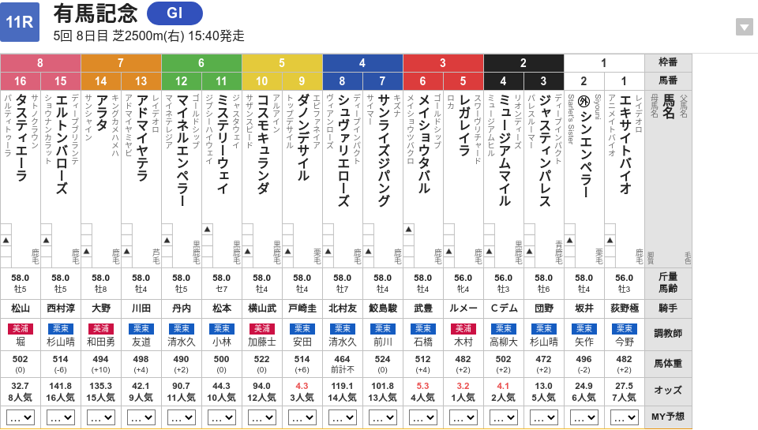

## 4. 単勝予測結果

### 【中山大障害(J.GⅠ) 2025/12/27(土)】

| 枠番 | 馬番 | 人気 | オッズ | 馬名 | 騎手 | 調教師 | 予測タイム(sec) | 1_順位 | 1-3着内確率(%) | 2_順位 | ﾀﾞｰｸﾎｰｽ確率(%) | 3_順位 |
| --- | --- | --- | --- | --- | --- | --- | --- | --- | --- | --- | --- | --- |
| 1 | 1 | 2 | 3.7 | ネビーイーム | 小牧加矢太 | 佐々木晶三 | 290.2 | 6.0 | 25.6 | 2 | 0.6 | 8 |
| 2 | 2 | 8 | 138.0 | タマモエース | 小野寺祐太 | 宮地貴稔 | 288.5 | 3.0 | 11.4 | 8 | 40.6 | 3 |
| 3 | 3 | 5 | 29.7 | ピーターサイト | 森一馬 | 村田一誠 | 289.6 | 4.5 | 18.3 | 5 | 1.9 | 6 |
| 4 | 4 | 1 | 1.5 | エコロデュエル | 草野太郎 | 岩戸孝樹 | 276.1 | 1.0 | 29.0 | 1 | 0.5 | 9 |
| 5 | 5 | 10 | 206.1 | タンジェントアーク | 五十嵐雄祐 | 田村康仁 | 288.4 | 2.0 | 11.9 | 7 | 60.2 | 1 |
| 6 | 6 | 3 | 5.3 | ジューンベロシティ | 高田潤 | 武英智 | 295.9 | 10.0 | 21.2 | 4 | 0.4 | 10 |
| 7 | 7 | 4 | 10.6 | フェーレンベルク | 上野翔 | 千葉直人 | 289.6 | 4.5 | 21.3 | 3 | 1.3 | 7 |
| 7 | 8 | 9 | 163.9 | アルデドゥオーモ | 伴啓太 | 矢野英一 | 292.9 | 7.0 | 12.1 | 6 | 57.7 | 2 |
| 8 | 9 | 6 | 73.6 | プラチナドリーム | 石神深一 | 菊川正達 | 295.2 | 8.0 | 4.2 | 9 | 14.6 | 5 |
| 8 | 10 | 7 | 101.3 | メイショウアツイタ | 難波剛健 | 高橋義忠 | 295.6 | 9.0 | 3.9 | 10 | 20.4 | 4 |

### 【ホープフルステークス(GⅠ) 2025/12/27(土)】

| 枠番 | 馬番 | 人気 | オッズ | 馬名 | 騎手 | 調教師 | 予測タイム(sec) | 1_順位 | 1-3着内確率(%) | 2_順位 | ﾀﾞｰｸﾎｰｽ確率(%) | 3_順位 |
| --- | --- | --- | --- | --- | --- | --- | --- | --- | --- | --- | --- | --- |
| 1 | 1 | 10 | 37.9 | ノチェセラーダ | Ａ．プーシャン | 杉山佳明 | 127.4 | 10.5 | 19.7 | 10 | 40.5 | 8.0 |
| 1 | 2 | 6 | 16.0 | アーレムアレス | 菱田裕二 | 橋口慎介 | 127.4 | 10.5 | 30.2 | 1 | 1.2 | 11.0 |
| 2 | 3 | 2 | 4.6 | ジャスティンビスタ | 北村友一 | 吉岡辰弥 | 121.4 | 1.5 | 28.4 | 2 | 0.6 | 12.0 |
| 2 | 4 | 7 | 19.8 | ロブチェン | 松山弘平 | 杉山晴紀 | 127.4 | 10.5 | 24.6 | 5 | 1.8 | 9.0 |
| 3 | 5 | 16 | 279.1 | ノーウェアマン | 木幡巧也 | 浅利英明 | 127.4 | 10.5 | 11.9 | 14 | 60.1 | 1.0 |
| 3 | 6 | 5 | 6.4 | バドリナート | 坂井瑠星 | 松永幹夫 | 127.4 | 10.5 | 23.7 | 6 | 0.6 | 13.0 |
| 4 | 7 | 13 | 87.8 | テーオーアルアイン | 横山武史 | 奥村豊 | 127.4 | 10.5 | 11.7 | 15 | 46.2 | 4.0 |
| 4 | 8 | 15 | 151.9 | マテンロウゼロ | 横山典弘 | 松永幹夫 | 127.4 | 10.5 | 11.6 | 16 | 58.8 | 2.5 |
| 5 | 9 | 14 | 133.0 | メイショウハチコウ | 三浦皇成 | 牧浦充徳 | 127.4 | 10.5 | 12.2 | 12 | 58.8 | 2.5 |
| 5 | 10 | 12 | 62.0 | ウイナーズナイン | 西村淳也 | 小栗実 | 127.4 | 10.5 | 12.2 | 13 | 44.2 | 5.0 |

[output cut: 6 more lines]

### 【阪神カップ(GⅡ) 2025/12/27(土)】

| 枠番 | 馬番 | 人気 | オッズ | 馬名 | 騎手 | 調教師 | 予測タイム(sec) | 1_順位 | 1-3着内確率(%) | 2_順位 | ﾀﾞｰｸﾎｰｽ確率(%) | 3_順位 |
| --- | --- | --- | --- | --- | --- | --- | --- | --- | --- | --- | --- | --- |
| 1 | 1 | 8 | 25.8 | エイシンフェンサー | 川又賢治 | 吉村圭司 | 83.4 | 7 | 17.4 | 6 | 1.7 | 9 |
| 1 | 2 | 7 | 23.7 | ヨシノイースター | 内田博幸 | 中尾秀正 | 87.1 | 12 | 6.3 | 13 | 1.5 | 11 |
| 2 | 3 | 13 | 152.0 | グレイイングリーン | 吉村誠之助 | 池江泰寿 | 86.6 | 11 | 5.8 | 14 | 12.5 | 8 |
| 2 | 4 | 15 | 310.4 | カリボール | 富田暁 | 西村真幸 | 88.0 | 15 | 4.9 | 15 | 12.8 | 7 |
| 3 | 5 | 12 | 134.5 | シャドウフューリー | 泉谷楓真 | 杉山晴紀 | 83.3 | 3 | 12.2 | 9 | 37.0 | 2 |
| 3 | 6 | 10 | 90.3 | シュタールヴィント | 高杉吏麒 | 矢作芳人 | 87.7 | 14 | 3.2 | 16 | 30.1 | 5 |
| 4 | 7 | 4 | 8.1 | フォーチュンタイム | 団野大成 | 吉岡辰弥 | 83.4 | 6 | 45.4 | 1 | 0.7 | 15 |
| 4 | 8 | 16 | 348.0 | アスクワンタイム | 西塚洸二 | 梅田智之 | 84.8 | 9 | 7.4 | 12 | 53.5 | 1 |
| 5 | 9 | 2 | 6.4 | ジューンブレア | 武豊 | 武英智 | 82.5 | 2 | 40.4 | 2 | 0.7 | 14 |
| 5 | 10 | 9 | 29.5 | グロリアラウス | Ｆ．ジェルー | 斉藤崇史 | 83.8 | 8 | 14.5 | 8 | 34.2 | 3 |

[output cut: 6 more lines]

### 【有馬記念(GⅠ) 2025/12/28(日)】

| 枠番 | 馬番 | 人気 | オッズ | 馬名 | 騎手 | 調教師 | 予測タイム(sec) | 1_順位 | 1-3着内確率(%) | 2_順位 | ﾀﾞｰｸﾎｰｽ確率(%) | 3_順位 |
| --- | --- | --- | --- | --- | --- | --- | --- | --- | --- | --- | --- | --- |
| 1 | 1 | 7 | 29.7 | エキサイトバイオ | 荻野極 | 今野貞一 | 159.8 | 13.0 | 18.1 | 7 | 1.8 | 10 |
| 1 | 2 | 6 | 26.6 | シンエンペラー | 坂井瑠星 | 矢作芳人 | 157.9 | 8.5 | 21.5 | 5 | 1.6 | 12 |
| 2 | 3 | 5 | 12.7 | ジャスティンパレス | 団野大成 | 杉山晴紀 | 161.9 | 14.0 | 35.2 | 2 | 1.8 | 11 |
| 2 | 4 | 3 | 3.8 | ミュージアムマイル | Ｃ．デムーロ | 高柳大輔 | 151.9 | 2.0 | 29.1 | 3 | 0.6 | 14 |
| 3 | 5 | 1 | 3.3 | レガレイラ | Ｃ．ルメール | 木村哲也 | 151.9 | 2.0 | 35.4 | 1 | 0.7 | 13 |
| 3 | 6 | 4 | 5.8 | メイショウタバル | 武豊 | 石橋守 | 157.9 | 8.5 | 17.3 | 8 | 0.5 | 16 |
| 4 | 7 | 13 | 122.5 | サンライズジパング | 鮫島克駿 | 前川恭子 | 159.7 | 12.0 | 5.1 | 12 | 11.4 | 8 |
| 4 | 8 | 14 | 154.1 | シュヴァリエローズ | 北村友一 | 清水久詞 | 155.5 | 4.0 | 6.0 | 11 | 48.3 | 1 |
| 5 | 9 | 2 | 3.8 | ダノンデサイル | 戸崎圭太 | 安田翔伍 | 151.9 | 2.0 | 21.1 | 6 | 0.6 | 15 |
| 5 | 10 | 12 | 111.5 | コスモキュランダ | 横山武史 | 加藤士津八 | 165.2 | 16.0 | 4.3 | 16 | 15.7 | 7 |

[output cut: 6 more lines]

## 5. 人気と着順の乖離率推移

### 【中山大障害_1999y_2019y】

[interactive chart not shown]

### 【ホープフルステークス_2014y_2019y】

[interactive chart not shown]

### 【阪神カップ_1990y_2019y】

[interactive chart not shown]

### 【有馬記念_1990y_2019y】

[interactive chart not shown]

### 【中山大障害_1999y_2019y】

| No | 開催年 | 不整合率(%) | 頭数 | 人気別着順(1-3位) | 人気別着順(全体) |
| --- | --- | --- | --- | --- | --- |
| 21 | 2019 | 38.9 | 15頭 | 2-6-4 | 2\|6\|4\|1\|8\|7\|5\|12\|11\|3\|14\|9\|13\|15\|10 |
| 20 | 2018 | 36.8 | 12頭 | 3-5-6 | 3\|5\|6\|7\|2\|11\|4\|9\|12\|8\|10\|13 |
| 19 | 2017 | 10.0 | 15頭 | 1-2-5 | 1\|2\|5\|3\|6\|11\|4\|8\|7\|9\|10\|15\|12\|13\|14 |
| 18 | 2016 | 6.3 | 11頭 | 1-2-3 | 1\|2\|3\|5\|8\|4\|10\|6\|7\|9\|11 |
| 17 | 2015 | 35.0 | 13頭 | 2-5-1 | 2\|5\|1\|9\|12\|6\|7\|8\|10\|11\|4\|13\|14 |
| 16 | 2014 | 35.7 | 12頭 | 4-1-3 | 4\|1\|3\|10\|2\|9\|5\|8\|12\|6\|7\|11 |
| 15 | 2013 | 31.8 | 15頭 | 5-8-2 | 5\|8\|2\|1\|3\|10\|12\|16\|4\|6\|9\|7\|14\|13\|15 |
| 14 | 2012 | 43.3 | 15頭 | 3-2-1 | 3\|2\|1\|7\|4\|8\|6\|5\|14\|15\|13\|11\|10\|12\|9 |
| 13 | 2011 | 23.5 | 10頭 | 1-3-4 | 1\|3\|4\|2\|5\|8\|7\|10\|9\|6 |
| 12 | 2010 | 69.5 | 10頭 | 10-4-5 | 10\|4\|5\|9\|2\|11\|3\|6\|12\|1 |

[output cut: 11 more lines]

### 【ホープフルステークス_2014y_2019y】

| No | 開催年 | 不整合率(%) | 頭数 | 人気別着順(1-3位) | 人気別着順(全体) |
| --- | --- | --- | --- | --- | --- |
| 6 | 2019 | 20.2 | 13頭 | 1-3-2 | 1\|3\|2\|6\|4\|12\|7\|11\|5\|10\|9\|8\|13 |
| 5 | 2018 | 4.7 | 13頭 | 1-2-3 | 1\|2\|3\|8\|4\|5\|9\|6\|7\|13\|10\|12\|11 |
| 4 | 2017 | 28.1 | 16頭 | 1-4-8 | 1\|4\|8\|5\|10\|2\|11\|12\|13\|17\|15\|9\|3\|7\|14\|16 |
| 3 | 2016 | 14.8 | 14頭 | 1-8-2 | 1\|8\|2\|6\|3\|7\|10\|13\|4\|14\|5\|9\|11\|12 |
| 2 | 2015 | 29.7 | 12頭 | 3-1-2 | 3\|1\|2\|6\|4\|5\|7\|8\|11\|12\|9\|10 |
| 1 | 2014 | 44.6 | 17頭 | 2-8-9 | 2\|8\|9\|5\|11\|12\|4\|6\|1\|16\|3\|7\|10\|13\|15\|14\|17 |

### 【阪神カップ_1990y_2019y】

| No | 開催年 | 不整合率(%) | 頭数 | 人気別着順(1-3位) | 人気別着順(全体) |
| --- | --- | --- | --- | --- | --- |
| 30 | 2019 | 30.9 | 11頭 | 1-6-10 | 1\|6\|10\|9\|4\|2\|8\|5\|7\|3\|11 |
| 29 | 2018 | 42.9 | 11頭 | 3-4-1 | 3\|4\|1\|2\|6\|7\|10\|5\|9\|8\|11 |
| 28 | 2017 | 14.0 | 10頭 | 1-2-5 | 1\|2\|5\|6\|8\|9\|3\|10\|4\|7 |
| 27 | 2016 | 33.9 | 11頭 | 1-4-3 | 1\|4\|3\|9\|8\|5\|2\|6\|7\|11\|10 |
| 26 | 2015 | 14.4 | 10頭 | 1-7-2 | 1\|7\|2\|6\|8\|3\|9\|4\|5\|10 |
| 25 | 2014 | 26.7 | 9頭 | 1-5-3 | 1\|5\|3\|2\|4\|7\|9\|6\|8 |
| 24 | 2013 | 23.6 | 9頭 | 1-3-5 | 1\|3\|5\|2\|4\|9\|8\|6\|7 |
| 23 | 2012 | 37.0 | 11頭 | 3-1-5 | 3\|1\|5\|2\|4\|8\|10\|7\|9\|6\|12 |
| 22 | 2011 | 42.2 | 13頭 | 3-1-6 | 3\|1\|6\|7\|11\|5\|12\|2\|4\|8\|10\|9\|13 |
| 21 | 2010 | 47.2 | 14頭 | 5-4-1 | 5\|4\|1\|6\|3\|13\|8\|14\|2\|7\|11\|10\|12\|9 |

[output cut: 20 more lines]

### 【有馬記念_1990y_2019y】

| No | 開催年 | 不整合率(%) | 頭数 | 人気別着順(1-3位) | 人気別着順(全体) |
| --- | --- | --- | --- | --- | --- |
| 30 | 2019 | 38.4 | 16頭 | 2-3-4 | 2\|3\|4\|6\|7\|14\|9\|8\|1\|10\|15\|5\|13\|12\|11\|16 |
| 29 | 2018 | 35.2 | 16頭 | 3-1-9 | 3\|1\|9\|8\|2\|6\|15\|4\|5\|12\|10\|13\|16\|7\|11\|14 |
| 28 | 2017 | 31.8 | 16頭 | 1-8-3 | 1\|8\|3\|2\|10\|7\|14\|9\|11\|6\|5\|12\|4\|15\|16\|13 |
| 27 | 2016 | 12.0 | 16頭 | 1-2-3 | 1\|2\|3\|8\|7\|5\|10\|4\|11\|6\|9\|15\|13\|16\|12\|14 |
| 26 | 2015 | 53.4 | 16頭 | 8-5-4 | 8\|5\|4\|12\|2\|14\|11\|1\|10\|6\|7\|9\|13\|16\|15\|3 |
| 25 | 2014 | 38.8 | 16頭 | 4-9-1 | 4\|9\|1\|3\|2\|11\|7\|8\|16\|6\|13\|10\|5\|12\|14\|15 |
| 24 | 2013 | 22.5 | 16頭 | 1-4-2 | 1\|4\|2\|12\|16\|6\|7\|13\|15\|8\|3\|14\|10\|5\|9\|11 |
| 23 | 2012 | 8.2 | 16頭 | 1-10-2 | 1\|10\|2\|3\|7\|4\|5\|6\|8\|12\|14\|13\|9\|15\|16\|11 |
| 22 | 2011 | 28.4 | 13頭 | 1-7-9 | 1\|7\|9\|11\|3\|8\|2\|4\|6\|5\|12\|10\|13 |
| 21 | 2010 | 26.5 | 15頭 | 2-1-14 | 2\|1\|14\|3\|7\|6\|5\|12\|10\|13\|8\|9\|4\|11\|15 |

[output cut: 20 more lines]

## 6. 1-3番人気馬の着順分類予測

### 【中山大障害】

| 分類 | 凡例 | 発生確率(%) | 当該レース | 当該レースランク | 直近1年間 |
| --- | --- | --- | --- | --- | --- |
| 4: 1,2番人気のみ (4_pop12) | 1 \| 2 \| * | 16.8 | 1.40 | 1.04 | 0.00 |
| 1: 1番人気のみ (1_pop1) | 1 \| * \| * | 15.7 | 3.92 | 1.33 | 0.00 |
| 5: 1,3番人気のみ (5_pop13) | 1 \| 3 \| * | 15.1 | 1.89 | 1.14 | 0.60 |
| 8: 1,2,3番人気すべて着外 (8_darkhorse) | * \| * \| * | 14.3 | 0.71 | 1.08 | 0.00 |
| 2: 2番人気のみ (2_pop2) | 2 \| * \| * | 12.2 | 0.38 | 0.92 | 0.49 |
| 3: 3番人気のみ (3_pop3) | 3 \| * \| * | 9.1 | 2.27 | 2.07 | 0.00 |
| 6: 2,3番人気のみ (6_pop23) | 2 \| 3 \| * | 9.1 | 0.76 | 0.69 | 0.36 |
| 7: 1,2,3番人気すべて着内 (7_pop123) | 1 \| 2 \| 3 | 7.7 | 0.96 | 0.52 | 0.31 |

### 【ホープフルステークス】

| 分類 | 凡例 | 発生確率(%) | 当該レース | 当該レースランク | 直近1年間 |
| --- | --- | --- | --- | --- | --- |
| 4: 1,2番人気のみ (4_pop12) | 1 \| 2 \| * | 16.6 | 1.82 | 1.02 | 0.00 |
| 1: 1番人気のみ (1_pop1) | 1 \| * \| * | 15.4 | 1.69 | 1.31 | 0.00 |
| 5: 1,3番人気のみ (5_pop13) | 1 \| 3 \| * | 14.7 | 0.00 | 1.11 | 0.59 |
| 8: 1,2,3番人気すべて着外 (8_darkhorse) | * \| * \| * | 13.9 | 0.00 | 1.05 | 0.00 |
| 7: 1,2,3番人気すべて着内 (7_pop123) | 1 \| 2 \| 3 | 11.6 | 0.16 | 0.79 | 0.46 |
| 2: 2番人気のみ (2_pop2) | 2 \| * \| * | 10.0 | 1.10 | 0.76 | 0.40 |
| 3: 3番人気のみ (3_pop3) | 3 \| * \| * | 8.9 | 0.00 | 2.02 | 0.00 |
| 6: 2,3番人気のみ (6_pop23) | 2 \| 3 \| * | 8.9 | 0.00 | 0.67 | 0.36 |

### 【阪神カップ】

| 分類 | 凡例 | 発生確率(%) | 当該レース | 当該レースランク | 直近1年間 |
| --- | --- | --- | --- | --- | --- |
| 1: 1番人気のみ (1_pop1) | 1 \| * \| * | 17.8 | 1.24 | 1.35 | 0.00 |
| 4: 1,2番人気のみ (4_pop12) | 1 \| 2 \| * | 17.0 | 1.19 | 1.08 | 0.00 |
| 5: 1,3番人気のみ (5_pop13) | 1 \| 3 \| * | 15.2 | 0.59 | 0.64 | 0.61 |
| 8: 1,2,3番人気すべて着外 (8_darkhorse) | * \| * \| * | 13.5 | 1.57 | 1.71 | 0.00 |
| 2: 2番人気のみ (2_pop2) | 2 \| * \| * | 10.4 | 1.21 | 0.99 | 0.42 |
| 3: 3番人気のみ (3_pop3) | 3 \| * \| * | 9.6 | 3.31 | 3.69 | 0.00 |
| 6: 2,3番人気のみ (6_pop23) | 2 \| 3 \| * | 9.3 | 1.63 | 1.75 | 0.37 |
| 7: 1,2,3番人気すべて着内 (7_pop123) | 1 \| 2 \| 3 | 7.3 | 0.36 | 0.35 | 0.29 |

### 【有馬記念】

| 分類 | 凡例 | 発生確率(%) | 当該レース | 当該レースランク | 直近1年間 |
| --- | --- | --- | --- | --- | --- |
| 4: 1,2番人気のみ (4_pop12) | 1 \| 2 \| * | 16.8 | 0.73 | 0.73 | 0.00 |
| 1: 1番人気のみ (1_pop1) | 1 \| * \| * | 15.7 | 0.92 | 0.92 | 0.00 |
| 5: 1,3番人気のみ (5_pop13) | 1 \| 3 \| * | 15.1 | 0.75 | 0.75 | 0.00 |
| 8: 1,2,3番人気すべて着外 (8_darkhorse) | * \| * \| * | 14.3 | 1.25 | 1.25 | 0.00 |
| 2: 2番人気のみ (2_pop2) | 2 \| * \| * | 12.2 | 4.21 | 4.21 | 0.00 |
| 3: 3番人気のみ (3_pop3) | 3 \| * \| * | 9.1 | 1.60 | 1.60 | 0.00 |
| 6: 2,3番人気のみ (6_pop23) | 2 \| 3 \| * | 9.1 | 0.53 | 0.53 | 0.09 |
| 7: 1,2,3番人気すべて着内 (7_pop123) | 1 \| 2 \| 3 | 7.7 | 2.66 | 2.66 | 0.00 |

## 7. 3連複予測結果

### 【中山大障害(J.GⅠ) 2025/12/27(土)】

| 分類 | 馬番 | 枠番 | 人気 | 平均予測タイム(sec) | 1-3着内確率(%) | ﾀﾞｰｸﾎｰｽ確率(%) | 馬名 | 騎手 | 調教師 |
| --- | --- | --- | --- | --- | --- | --- | --- | --- | --- |
| 4: 1,2番人気のみ (4_pop12) | 4-1-7 | 4-1-7 | 1-2-4 | 285.30 | 1.59 | 0.00 | エコロデュエル \| ネビーイーム \| フェーレンベルク | 草野太郎 \| 小牧加矢太 \| 上野翔 | 岩戸孝樹 \| 佐々木晶三 \| 千葉直人 |
| 7: 1,2,3番人気すべて着内 (7_pop123) | 4-1-6 | 4-1-6 | 1-2-3 | 287.40 | 1.58 | 0.00 | エコロデュエル \| ネビーイーム \| ジューンベロシティ | 草野太郎 \| 小牧加矢太 \| 高田潤 | 岩戸孝樹 \| 佐々木晶三 \| 武英智 |
| 4: 1,2番人気のみ (4_pop12) | 4-1-3 | 4-1-3 | 1-2-5 | 285.30 | 1.36 | 0.00 | エコロデュエル \| ネビーイーム \| ピーターサイト | 草野太郎 \| 小牧加矢太 \| 森一馬 | 岩戸孝樹 \| 佐々木晶三 \| 村田一誠 |
| 5: 1,3番人気のみ (5_pop13) | 4-6-7 | 4-6-7 | 1-3-4 | 287.20 | 1.31 | 0.00 | エコロデュエル \| ジューンベロシティ \| フェーレンベルク | 草野太郎 \| 高田潤 \| 上野翔 | 岩戸孝樹 \| 武英智 \| 千葉直人 |
| 6: 2,3番人気のみ (6_pop23) | 1-6-7 | 1-6-7 | 2-3-4 | 291.90 | 1.16 | 0.00 | ネビーイーム \| ジューンベロシティ \| フェーレンベルク | 小牧加矢太 \| 高田潤 \| 上野翔 | 佐々木晶三 \| 武英智 \| 千葉直人 |
| 1: 1番人気のみ (1_pop1) | 4-7-3 | 4-7-3 | 1-4-5 | 285.10 | 1.13 | 0.00 | エコロデュエル \| フェーレンベルク \| ピーターサイト | 草野太郎 \| 上野翔 \| 森一馬 | 岩戸孝樹 \| 千葉直人 \| 村田一誠 |
| 5: 1,3番人気のみ (5_pop13) | 4-6-3 | 4-6-3 | 1-3-5 | 287.20 | 1.13 | 0.00 | エコロデュエル \| ジューンベロシティ \| ピーターサイト | 草野太郎 \| 高田潤 \| 森一馬 | 岩戸孝樹 \| 武英智 \| 村田一誠 |
| 2: 2番人気のみ (2_pop2) | 1-7-3 | 1-7-3 | 2-4-5 | 289.80 | 1.00 | 0.00 | ネビーイーム \| フェーレンベルク \| ピーターサイト | 小牧加矢太 \| 上野翔 \| 森一馬 | 佐々木晶三 \| 千葉直人 \| 村田一誠 |
| 6: 2,3番人気のみ (6_pop23) | 1-6-3 | 1-6-3 | 2-3-5 | 291.90 | 1.00 | 0.00 | ネビーイーム \| ジューンベロシティ \| ピーターサイト | 小牧加矢太 \| 高田潤 \| 森一馬 | 佐々木晶三 \| 武英智 \| 村田一誠 |
| 4: 1,2番人気のみ (4_pop12) | 4-1-8 | 4-1-7 | 1-2-9 | 286.40 | 0.90 | 0.00 | エコロデュエル \| ネビーイーム \| アルデドゥオーモ | 草野太郎 \| 小牧加矢太 \| 伴啓太 | 岩戸孝樹 \| 佐々木晶三 \| 矢野英一 |

[output cut: 110 more lines]

### 【ホープフルステークス(GⅠ) 2025/12/27(土)】

| 分類 | 馬番 | 枠番 | 人気 | 平均予測タイム(sec) | 1-3着内確率(%) | ﾀﾞｰｸﾎｰｽ確率(%) | 馬名 | 騎手 | 調教師 |
| --- | --- | --- | --- | --- | --- | --- | --- | --- | --- |
| 6: 2,3番人気のみ (6_pop23) | 3-13-2 | 2-7-1 | 2-3-6 | 124.43 | 2.30 | 0.00 | ジャスティンビスタ \| ショウナンガルフ \| アーレムアレス | 北村友一 \| 池添謙一 \| 菱田裕二 | 吉岡辰弥 \| 須貝尚介 \| 橋口慎介 |
| 4: 1,2番人気のみ (4_pop12) | 12-3-2 | 6-2-1 | 1-2-6 | 123.40 | 2.30 | 0.00 | アンドゥーリル \| ジャスティンビスタ \| アーレムアレス | 川田将雅 \| 北村友一 \| 菱田裕二 | 中内田充正 \| 吉岡辰弥 \| 橋口慎介 |
| 5: 1,3番人気のみ (5_pop13) | 12-13-2 | 6-7-1 | 1-3-6 | 124.43 | 2.18 | 0.00 | アンドゥーリル \| ショウナンガルフ \| アーレムアレス | 川田将雅 \| 池添謙一 \| 菱田裕二 | 中内田充正 \| 須貝尚介 \| 橋口慎介 |
| 2: 2番人気のみ (2_pop2) | 3-2-4 | 2-1-2 | 2-6-7 | 125.40 | 2.11 | 0.00 | ジャスティンビスタ \| アーレムアレス \| ロブチェン | 北村友一 \| 菱田裕二 \| 松山弘平 | 吉岡辰弥 \| 橋口慎介 \| 杉山晴紀 |
| 7: 1,2,3番人気すべて着内 (7_pop123) | 12-3-13 | 6-2-7 | 1-2-3 | 122.43 | 2.05 | 0.00 | アンドゥーリル \| ジャスティンビスタ \| ショウナンガルフ | 川田将雅 \| 北村友一 \| 池添謙一 | 中内田充正 \| 吉岡辰弥 \| 須貝尚介 |
| 2: 2番人気のみ (2_pop2) | 3-6-2 | 2-3-1 | 2-5-6 | 125.40 | 2.03 | 0.00 | ジャスティンビスタ \| バドリナート \| アーレムアレス | 北村友一 \| 坂井瑠星 \| 菱田裕二 | 吉岡辰弥 \| 松永幹夫 \| 橋口慎介 |
| 3: 3番人気のみ (3_pop3) | 13-2-4 | 7-1-2 | 3-6-7 | 126.43 | 2.00 | 0.00 | ショウナンガルフ \| アーレムアレス \| ロブチェン | 池添謙一 \| 菱田裕二 \| 松山弘平 | 須貝尚介 \| 橋口慎介 \| 杉山晴紀 |
| 1: 1番人気のみ (1_pop1) | 12-2-4 | 6-1-2 | 1-6-7 | 125.40 | 1.99 | 0.00 | アンドゥーリル \| アーレムアレス \| ロブチェン | 川田将雅 \| 菱田裕二 \| 松山弘平 | 中内田充正 \| 橋口慎介 \| 杉山晴紀 |
| 3: 3番人気のみ (3_pop3) | 13-6-2 | 7-3-1 | 3-5-6 | 126.43 | 1.92 | 0.00 | ショウナンガルフ \| バドリナート \| アーレムアレス | 池添謙一 \| 坂井瑠星 \| 菱田裕二 | 須貝尚介 \| 松永幹夫 \| 橋口慎介 |
| 1: 1番人気のみ (1_pop1) | 12-6-2 | 6-3-1 | 1-5-6 | 125.40 | 1.92 | 0.00 | アンドゥーリル \| バドリナート \| アーレムアレス | 川田将雅 \| 坂井瑠星 \| 菱田裕二 | 中内田充正 \| 松永幹夫 \| 橋口慎介 |

[output cut: 550 more lines]

### 【阪神カップ(GⅡ) 2025/12/27(土)】

| 分類 | 馬番 | 枠番 | 人気 | 平均予測タイム(sec) | 1-3着内確率(%) | ﾀﾞｰｸﾎｰｽ確率(%) | 馬名 | 騎手 | 調教師 |
| --- | --- | --- | --- | --- | --- | --- | --- | --- | --- |
| 2: 2番人気のみ (2_pop2) | 9-7-11 | 5-4-6 | 2-4-5 | 83.07 | 6.08 | 0.00 | ジューンブレア \| フォーチュンタイム \| ダノンマッキンリー | 武豊 \| 団野大成 \| Ｃ．デムーロ | 武英智 \| 吉岡辰弥 \| 藤原英昭 |
| 6: 2,3番人気のみ (6_pop23) | 9-15-7 | 5-8-4 | 2-3-4 | 84.37 | 4.90 | 0.00 | ジューンブレア \| ルガル \| フォーチュンタイム | 武豊 \| 鮫島克駿 \| 団野大成 | 武英智 \| 杉山晴紀 \| 吉岡辰弥 |
| 3: 3番人気のみ (3_pop3) | 15-7-11 | 8-4-6 | 3-4-5 | 84.63 | 4.01 | 0.00 | ルガル \| フォーチュンタイム \| ダノンマッキンリー | 鮫島克駿 \| 団野大成 \| Ｃ．デムーロ | 杉山晴紀 \| 吉岡辰弥 \| 藤原英昭 |
| 2: 2番人気のみ (2_pop2) | 9-7-13 | 5-4-7 | 2-4-6 | 83.67 | 3.57 | 0.00 | ジューンブレア \| フォーチュンタイム \| ミッキーゴージャス | 武豊 \| 団野大成 \| 横山和生 | 武英智 \| 吉岡辰弥 \| 安田翔伍 |
| 6: 2,3番人気のみ (6_pop23) | 9-15-11 | 5-8-6 | 2-3-5 | 84.33 | 3.57 | 0.00 | ジューンブレア \| ルガル \| ダノンマッキンリー | 武豊 \| 鮫島克駿 \| Ｃ．デムーロ | 武英智 \| 杉山晴紀 \| 藤原英昭 |
| 2: 2番人気のみ (2_pop2) | 9-7-1 | 5-4-1 | 2-4-8 | 83.10 | 3.20 | 0.00 | ジューンブレア \| フォーチュンタイム \| エイシンフェンサー | 武豊 \| 団野大成 \| 川又賢治 | 武英智 \| 吉岡辰弥 \| 吉村圭司 |
| 4: 1,2番人気のみ (4_pop12) | 12-9-7 | 6-5-4 | 1-2-4 | 81.80 | 3.01 | 0.00 | ナムラクレア \| ジューンブレア \| フォーチュンタイム | Ｃ．ルメール \| 武豊 \| 団野大成 | 長谷川浩大 \| 武英智 \| 吉岡辰弥 |
| 8: 1,2,3番人気すべて着外 (8_darkhorse) | 7-11-13 | 4-6-7 | 4-5-6 | 83.93 | 2.93 | 0.00 | フォーチュンタイム \| ダノンマッキンリー \| ミッキーゴージャス | 団野大成 \| Ｃ．デムーロ \| 横山和生 | 吉岡辰弥 \| 藤原英昭 \| 安田翔伍 |
| 2: 2番人気のみ (2_pop2) | 9-7-10 | 5-4-5 | 2-4-9 | 83.23 | 2.66 | 0.00 | ジューンブレア \| フォーチュンタイム \| グロリアラウス | 武豊 \| 団野大成 \| Ｆ．ジェルー | 武英智 \| 吉岡辰弥 \| 斉藤崇史 |
| 8: 1,2,3番人気すべて着外 (8_darkhorse) | 7-11-1 | 4-6-1 | 4-5-8 | 83.37 | 2.62 | 0.00 | フォーチュンタイム \| ダノンマッキンリー \| エイシンフェンサー | 団野大成 \| Ｃ．デムーロ \| 川又賢治 | 吉岡辰弥 \| 藤原英昭 \| 吉村圭司 |

[output cut: 550 more lines]

### 【有馬記念(GⅠ) 2025/12/28(日)】

| 分類 | 馬番 | 枠番 | 人気 | 平均予測タイム(sec) | 1-3着内確率(%) | ﾀﾞｰｸﾎｰｽ確率(%) | 馬名 | 騎手 | 調教師 |
| --- | --- | --- | --- | --- | --- | --- | --- | --- | --- |
| 4: 1,2番人気のみ (4_pop12) | 5-4-3 | 3-2-2 | 1-2-5 | 155.10 | 2.63 | 0.00 | レガレイラ \| ミュージアムマイル \| ジャスティンパレス | Ｃ．ルメール \| Ｃ．デムーロ \| 団野大成 | 木村哲也 \| 高柳大輔 \| 杉山晴紀 |
| 4: 1,2番人気のみ (4_pop12) | 5-4-2 | 3-2-1 | 1-2-6 | 153.80 | 2.55 | 0.00 | レガレイラ \| ミュージアムマイル \| シンエンペラー | Ｃ．ルメール \| Ｃ．デムーロ \| 坂井瑠星 | 木村哲也 \| 高柳大輔 \| 矢作芳人 |
| 1: 1番人気のみ (1_pop1) | 5-3-2 | 3-2-1 | 1-5-6 | 156.00 | 2.30 | 0.00 | レガレイラ \| ジャスティンパレス \| シンエンペラー | Ｃ．ルメール \| 団野大成 \| 坂井瑠星 | 木村哲也 \| 杉山晴紀 \| 矢作芳人 |
| 4: 1,2番人気のみ (4_pop12) | 5-4-16 | 3-2-8 | 1-2-8 | 153.03 | 2.26 | 0.00 | レガレイラ \| ミュージアムマイル \| タスティエーラ | Ｃ．ルメール \| Ｃ．デムーロ \| 松山弘平 | 木村哲也 \| 高柳大輔 \| 堀宣行 |
| 7: 1,2,3番人気すべて着内 (7_pop123) | 5-4-9 | 3-2-5 | 1-2-3 | 153.93 | 2.06 | 0.00 | レガレイラ \| ミュージアムマイル \| ダノンデサイル | Ｃ．ルメール \| Ｃ．デムーロ \| 戸崎圭太 | 木村哲也 \| 高柳大輔 \| 安田翔伍 |
| 1: 1番人気のみ (1_pop1) | 5-3-16 | 3-2-8 | 1-5-8 | 155.23 | 2.04 | 0.00 | レガレイラ \| ジャスティンパレス \| タスティエーラ | Ｃ．ルメール \| 団野大成 \| 松山弘平 | 木村哲也 \| 杉山晴紀 \| 堀宣行 |
| 1: 1番人気のみ (1_pop1) | 5-2-16 | 3-1-8 | 1-6-8 | 153.93 | 1.98 | 0.00 | レガレイラ \| シンエンペラー \| タスティエーラ | Ｃ．ルメール \| 坂井瑠星 \| 松山弘平 | 木村哲也 \| 矢作芳人 \| 堀宣行 |
| 2: 2番人気のみ (2_pop2) | 4-3-2 | 2-2-1 | 2-5-6 | 156.50 | 1.86 | 0.00 | ミュージアムマイル \| ジャスティンパレス \| シンエンペラー | Ｃ．デムーロ \| 団野大成 \| 坂井瑠星 | 高柳大輔 \| 杉山晴紀 \| 矢作芳人 |
| 5: 1,3番人気のみ (5_pop13) | 5-9-3 | 3-5-2 | 1-3-5 | 156.13 | 1.86 | 0.00 | レガレイラ \| ダノンデサイル \| ジャスティンパレス | Ｃ．ルメール \| 戸崎圭太 \| 団野大成 | 木村哲也 \| 安田翔伍 \| 杉山晴紀 |
| 5: 1,3番人気のみ (5_pop13) | 5-9-2 | 3-5-1 | 1-3-6 | 154.83 | 1.80 | 0.00 | レガレイラ \| ダノンデサイル \| シンエンペラー | Ｃ．ルメール \| 戸崎圭太 \| 坂井瑠星 | 木村哲也 \| 安田翔伍 \| 矢作芳人 |

[output cut: 550 more lines]

## 8. 直近の全レース情報

[output not shown]

[output cut: 6 more lines]